# Tutorial for R package CTSclocks

Huige Tong, Xiaolong Guo and Andrew E Teschendorff

Shanghai Institute of Nutrition and Health, CAS

tonghuige2021@sinh.ac.cn  
guoxiaolong2022@sinh.ac.cn  
andrew@sinh.ac.cn

31 July 2024

#### Abstract

CTSclocks is an R package which includes a number of cell-type specific epigenetic clocks so as to quantify biological age at cell-type resolution. At present, the package can be used to estimate DNAm-Age for neurons and glia in brain, and for hepatocytes in liver. In addition, the package also provides two tissue-specific clocks that allow estimation of DNAm-Age at the tissue level (for brain and liver).

#### Package

CTSclocks 0.0.1

# 1 Motivation and Background

The ability to accurately quantify biological age could help monitor and control healthy aging. Epigenetic clocks have emerged as promising tools for estimating biological age, yet so far, most of these clocks have been developed in the context of heterogeneous bulk tissues, which does not inform us about the biological age of individual cell-types. Thus, there is a need to develop epigenetic clocks that are not confounded by cell-type heterogeneity and that can yield biological age estimates at cell-type resolution. Here we present a tutorial on the implementation of cell-type and tissue-specific epigenetic DNA methylation-based clocks for brain and liver, focusing on 3 cell-types: neurons, glia and hepatocytes. In future, we hope to expand this package to include cell-type and tissue-specific clocks for a broader range of cell and tissue-types. Of note, all epigenetic clocks implemented in this package adjust for cell-type heterogeneity in the sense that the CpGs making up the clocks are not just tracking age-related changes in cell-type composition. The difference between the cell-type and tissue-specific clocks is that the cell-type specific ones are trained from CpGs that change with age specifically in the given cell-type (hence this is naturally adjusted for cell-type heterogeneity), whereas the tissue-specific clocks are trained on CpGs that change with age independently of cell-type compositional changes. Hence the latter don’t inform about which cell-types a CpG is changing in.

# 2 Data used in this tutorial

## 2.1 Bulk PFC data and sorted neuron data

- The bulk prefrontal cortex (PFC) data is from Murphy et al. This is an Illumina 450k dataset encompassing 38 normal PFC tissue samples and 37 PFC major depressive disorder samples. Only controls are used here. (MurphyGSE88890.rda)
- The sorted PFC neuron data is from Pai et al. This is an Illumina EPIC dataset encompassing 33 normal neuron tissue samples, 35 schizophrenia samples and 32 bipolar disorder neuron samples. Only controls are used here. (PaiGSE112179.rda)

## 2.2 A sample data of bulk liver

- The sample liver data from GSE107038 contains 39 normal liver samples and part of probes. (ExampleData_Liver.Rd)

## 2.3 Clocks for Brain

- Neu-In clock (Neu-InCoef.rda)
- Neu-Sin clock (Neu-SinCoef.rda)
- Glia-In clock (Glia-InCoef.rda)
- Glia-Sin clock (Glia-SinCoef.rda)
- Brain clock (BrainCoef.rda)

## 2.4 Clocks for Liver

- Hepatocyte clock (HepClock.rda)
- Liver clock (LiverClock.rda)

# 3 Application of Neu/Glia/Brain clocks

## 3.1 Neu-In, Glia-In and Brain clocks

- For bulk data, these clocks should be applied on centered and scaled to unit standard deviation residuals obtained after adjustment for cell-type fractions.
- For sorted data, these clocks should be applied on centered and scaled to unit standard deviation beta matrix.
- Here we apply Neu-In clock on a bulk PFC data from Murphy et al and a sorted neuron data from Pai et al. The Glia-In and Brain clocks work the same way with Neu-In clock.

### 3.1.1 Bulk data

```r
library(CTSclocks)

data(MurphyGSE88890)
agePred.v = CTSclockAge(beta.m, CTSclock = 'Neu-In', dataType = 'bulk', CTF.m = NULL, tissue = 'brain')
```

```
## [1] "Processing the data may take some time. Don't worry."
```

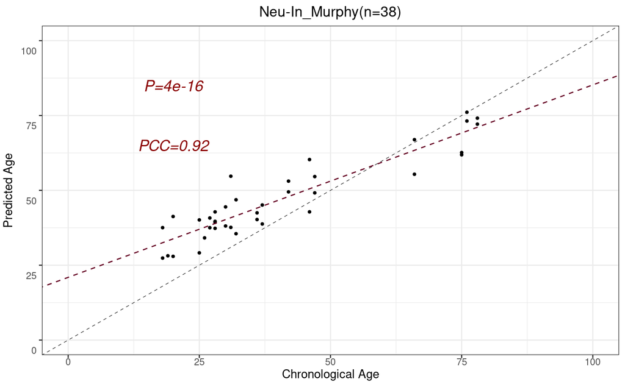

### 3.1.2 Sorted data

```r
library(CTSclocks)

data(PaiGSE112179)
agePred.v = CTSclockAge(beta.m, CTSclock = 'Neu-In', dataType = 'sorted', CTF.m = NULL, tissue = 'brain')
```

[figure not shown]

## 3.2 Neu-Sin and Glia-Sin clocks

### 3.2.1 Bulk data

```r
library(CTSclocks)

data(MurphyGSE88890)
agePred.v = CTSclockAge(beta.m, CTSclock = 'Neu-Sin', dataType = 'bulk', CTF.m = NULL, tissue = 'brain')
```

[figure not shown]

### 3.2.2 Sorted data

```r
library(CTSclocks)

data(PaiGSE112179)
agePred.v = CTSclockAge(beta.m, CTSclock = 'Neu-Sin', dataType = 'sorted', CTF.m = NULL, tissue = 'brain')
```

[figure not shown]

# 4 Application of Hepatocyte/Liver clocks

**For Hep clock**

```r
library(CTSclocks)

data(ExampleData_Liver)
agePred.v = CTSclockAge(Test.m, CTSclock = 'Hep', dataType = 'bulk', CTF.m = NULL, tissue = 'otherTissue')
```

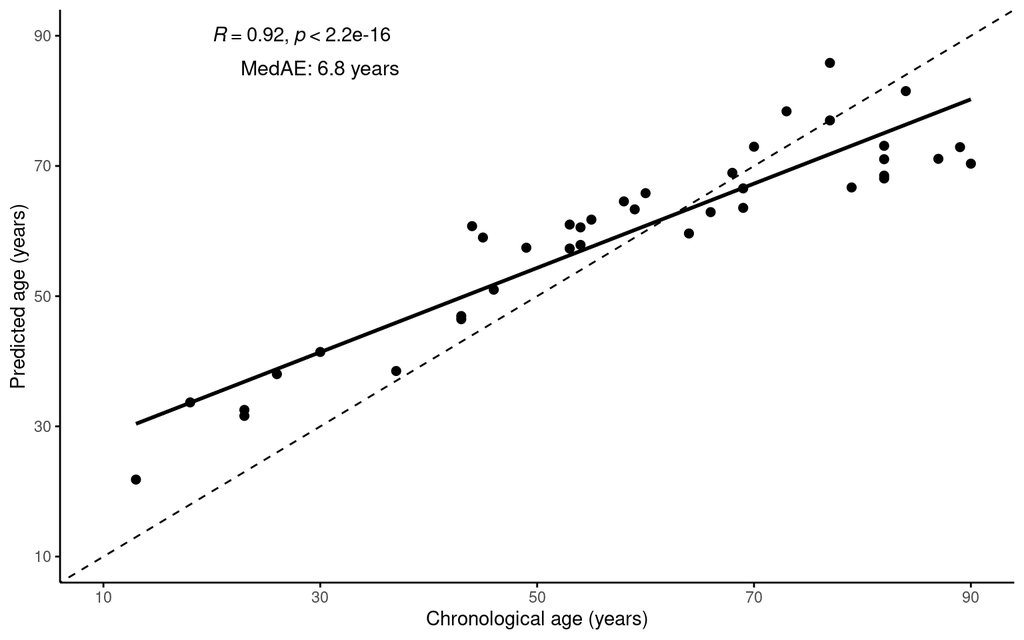

**Same steps for the liver clock**

```r
library(CTSclocks)

data(ExampleData_Liver)
agePred.v = CTSclockAge(Test.m, CTSclock = 'Liver', dataType = 'bulk', CTF.m = NULL, tissue = 'otherTissue')
```

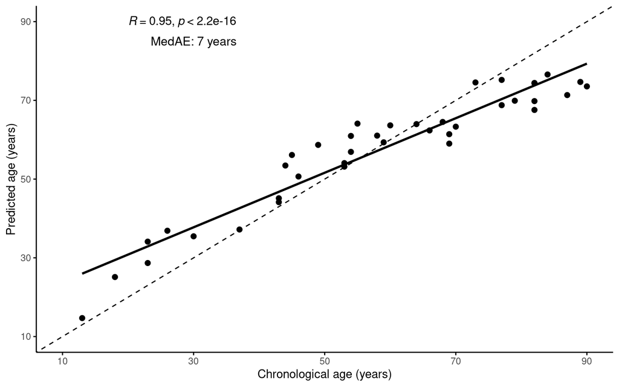

# 6 References

Huige Tong, Xiaolong Guo, Qi Luo and Andrew E Teschendorff. 2024. Cell-type specific epigenetic clocks to quantify biological age at cell-type resolution. Submitted.

Murphy, T. M., Crawford, B., Dempster, E. L., Hannon, E., Burrage, J., Turecki, G., Kaminsky, Z., & Mill, J. 2017. Methylomic profiling of cortex samples from completed suicide cases implicates a role for PSORS1C3 in major depression and suicide. Translational psychiatry, 7(1), e989.

Pai, S., Li, P., Killinger, B., Marshall, L., Jia, P., Liao, J., Petronis, A., Szabó, P. E., & Labrie, V. 2019. Differential methylation of enhancer at IGF2 is associated with abnormal dopamine synthesis in major psychosis. Nature communications, 10(1), 2046.

Bacalini, M. G., Franceschi, C., Gentilini, D., Ravaioli, F., Zhou, X., Remondini, D., Pirazzini, C., Giuliani, C., Marasco, E., Gensous, N., Di Blasio, A. M., Ellis, E., Gramignoli, R., Castellani, G., Capri, M., Strom, S., Nardini, C., Cescon, M., Grazi, G. L., & Garagnani, P. 2019. Molecular Aging of Human Liver: An Epigenetic/Transcriptomic Signature. The journals of gerontology. Series A, Biological sciences and medical sciences, 74(1), 1–8.